# Tidyverse en acción

# El Tidyverse

- Colección de paquetes de `R` diseñado para ciencia de datos.
- Todos los paquetes comparten la misma filosofía de diseño, gramática y estructuras de datos.
- Para tener la instalación completa:

```r
install.packages("tidyverse") # colección de paquetes

# Instalen tambien
install.packages("nycflights13") # Provee los datos que usaremos en ejemplos y ejercicios
install.packages("maps") # Permite hacer mapas
```

# El ciclo de análisis de datos

Wickham, H y Grolemund G. [*R for Data Science*](http://r4ds.had.co.nz/explore-intro.html)

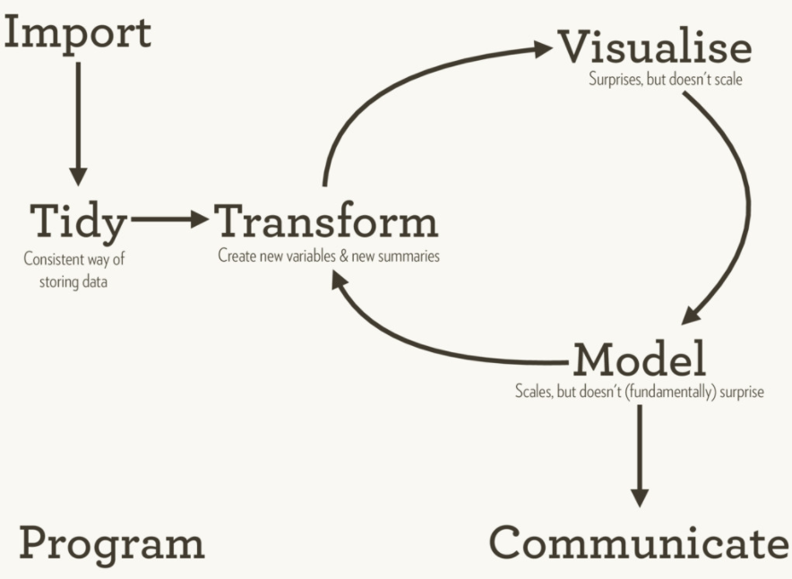

# El ciclo en paquetes

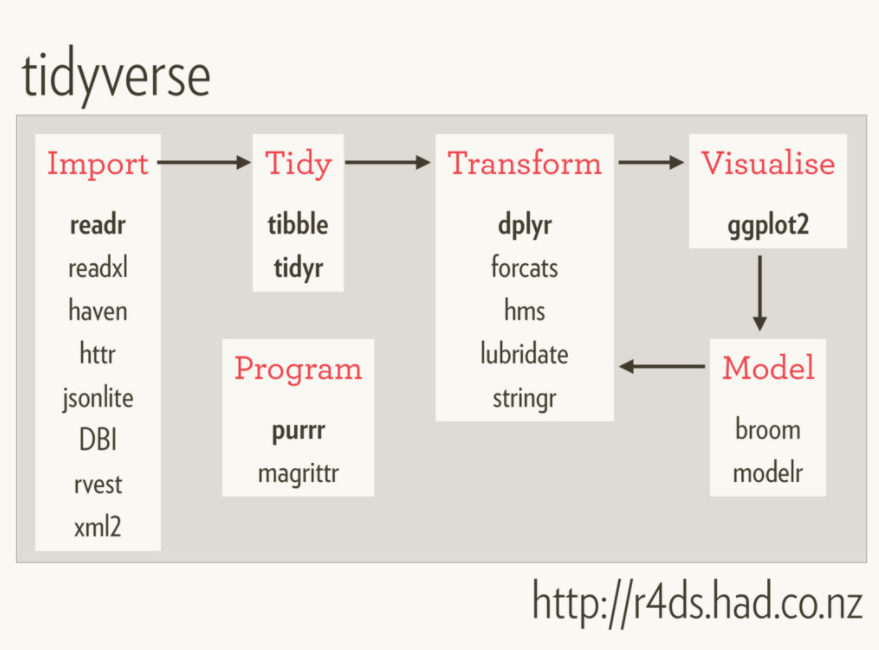

# Importación

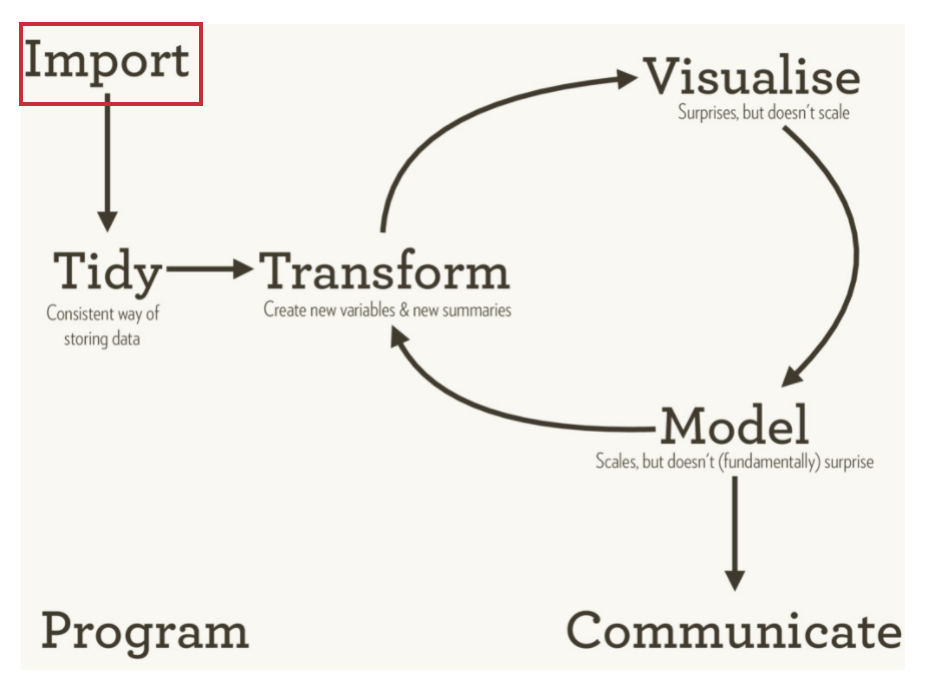

Paquetes útiles:

- readr
- readxl
- haven
- httr
- jsonlite
- DBI
- rvest
- xml2

| Formato | Lectura | Escritura |
| --- | --- | --- |
| rds | base::readRDS | base::saveRDS |
| separado por * | **readr::read_delim** | **readr::write_delim** |
| csv | **readr::read_csv** | **readr::write_csv** |
| Microsoft Excel | **readxl::read_excel** | xlsx::write.xlsx |
| dbf | foreign::read.dbf | foreign::write.dbf |
| IBM SPSS | **haven::read_sav** | **haven::write_sav** |
| Stata | **haven::read_dta** | foreign::write.dta |
| SAS | **haven::read_sas** | **haven::write_sas** |
| Google spreadsheet | googlesheets::gs_read | googlesheets::gs_new |

- En **negritas** funciones del tidyverse.

Los paquetes utilizados son (corre estos comandos en la consola):

```r
library(foreign)
library(haven)
library(readr)
library(readxl)
library(googlesheets)
```

**Importancia de rutas relativas**

El comando `getwd()` regresa el directorio al cual `R` esta dirigido en este momento.

Una buena practica es considerar el directorio de trabajo como el lugar en donde esta guardado el archivo o `script` en el que se trabaja y “moverse” desde ahí hasta el archivo que se quiere leer.

```r
getwd()
```

```
## [1] "C:/Users/animalito/Documents/learn/tidyverse-verbs"
```

Y para moverse *una carpeta arriba", se utiliza `..` (es recurrente: `../../../`.

Para moverse hacia adentro de la carpeta se escribe el nombre de la carpeta o archivo: `img/unaimagen.png`

**Algunos ejemplos**

**psv, tsv, etc**

`readr::write_delim`

```r
misdatos <- mtcars
write_delim(misdatos, path = "misdatos.psv", delim = "|")
```

```r
misdatos <- read_delim(file = "misdatos.psv", delim = "|")
# Los borramos
file.remove("misdatos.psv")
```

```
## [1] TRUE
```

**csv**

`readr::write_csv`

```r
# readr
write_csv(misdatos, path = "../misdatos.csv", na = "NA", append = FALSE)
```

Observa en el explorador de archivos en dónde es que se guardó el archivo `misdatos.csv`.

Para **leerlos**, seguimos usando rutas relativas.

```r
# readr - como tibble
misdatos <- read_csv("../misdatos.csv")

# Lo borro
file.remove("../misdatos.csv")
```

```
## [1] TRUE
```

**SPSS**

`haven::write_sav`

Para **escribirlos**

```r
# haven
write_sav(data = misdatos, path = "misdatos.sav")
```

Para **leerlos**

```r
# haven - como tibble
misdatos <- read_sav(file = "misdatos.sav", user_na = FALSE)

# Lo borro
file.remove("misdatos.sav")
```

```
## [1] TRUE
```

**Stata**

`haven::read_dta`

Para **escribirlos** en `Stata` primero tenemos que cambiar los nombres de las variables en el *data frame* pues `Stata` no admite puntos en los nombres:

```r
names(misdatos) <- tolower(gsub("\\.", "_", names(misdatos)))
# foreign
write.dta(data = misdatos, file = "~/misdatos.dta", version = 12)
```

Para **leerlos**

```r
# haven - como tibble
misdatos <- read_dta(file = "~/misdatos.dta", encoding = NULL)

# Lo borramos
file.remove("~/misdatos.dta")
```

```
## [1] TRUE
```

**Google Spreadsheet**

Para hacer este ejercicio, debes tener una cuenta de `gmail`.

Primero, debe realizarse la autenticación. Esto lo puedes hacer en cualquier sesión interactiva utilizando alguna función del paquete `googlesheets`

```r
gs_ls()
```

Ahora, vamos a **escribir** una nueva hoja en tu cuenta.

```r
gs_new("misdatos", ws_title = "mihoja", input = head(iris)
       , trim = TRUE, verbose = FALSE)
```

De igual forma, puedes ahora **leer** los datos de cualquier `google spreadsheet` que tengas en tu cuenta.

```r
misdatos <- gs_read(gs_title("misdatos"), ws = "mihoja")
# La borro
gs_delete(gs_title("misdatos"))
```

# Importación / Material adicional

- Libro base de este tutorial https://htmlpreview.github.io/?https://raw.githubusercontent.com/salimv19/ssR/master/aprendeR/importacion-de-datos.html
- Datacamp:
  - https://www.datacamp.com/courses/importing-data-in-r-part-1
  - https://www.datacamp.com/courses/working-with-data-in-the-tidyverse
- Cheatsheet https://www.rstudio.com/resources/cheatsheets/#import

# Transformación

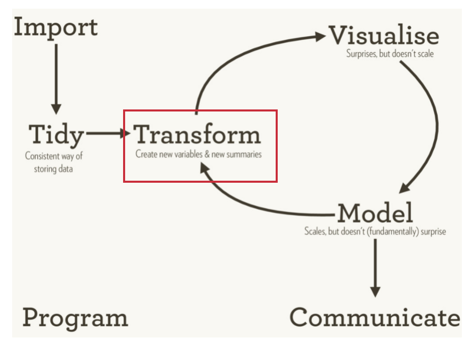

# Los verbos básicos en `dplyr`

[output not shown]

# Los verbos básicos en acción (saquen su compu)

```r
library(nycflights13)
library(tidyverse)
# Tablas con datos para ejercicios
data(package = "nycflights13")

# Tabla para los ejercicios iniciales
flights
```

```
## # A tibble: 336,776 x 19
##     year month   day dep_time sched_dep_time dep_delay arr_time
##    <int> <int> <int>    <int>          <int>     <dbl>    <int>
##  1  2013     1     1      517            515         2      830
##  2  2013     1     1      533            529         4      850
##  3  2013     1     1      542            540         2      923
##  4  2013     1     1      544            545        -1     1004
##  5  2013     1     1      554            600        -6      812
##  6  2013     1     1      554            558        -4      740
##  7  2013     1     1      555            600        -5      913
##  8  2013     1     1      557            600        -3      709
##  9  2013     1     1      557            600        -3      838
## 10  2013     1     1      558            600        -2      753
## # ... with 336,766 more rows, and 12 more variables: sched_arr_time <int>,
## #   arr_delay <dbl>, carrier <chr>, flight <int>, tailnum <chr>,
## #   origin <chr>, dest <chr>, air_time <dbl>, distance <dbl>, hour <dbl>,
## #   minute <dbl>, time_hour <dttm>
```

# filter

```r
filter(flights, month == 1, day == 1)
```

```
## # A tibble: 842 x 19
##     year month   day dep_time sched_dep_time dep_delay arr_time
##    <int> <int> <int>    <int>          <int>     <dbl>    <int>
##  1  2013     1     1      517            515         2      830
##  2  2013     1     1      533            529         4      850
##  3  2013     1     1      542            540         2      923
##  4  2013     1     1      544            545        -1     1004
##  5  2013     1     1      554            600        -6      812
##  6  2013     1     1      554            558        -4      740
##  7  2013     1     1      555            600        -5      913
##  8  2013     1     1      557            600        -3      709
##  9  2013     1     1      557            600        -3      838
## 10  2013     1     1      558            600        -2      753
## # ... with 832 more rows, and 12 more variables: sched_arr_time <int>,
## #   arr_delay <dbl>, carrier <chr>, flight <int>, tailnum <chr>,
## #   origin <chr>, dest <chr>, air_time <dbl>, distance <dbl>, hour <dbl>,
## #   minute <dbl>, time_hour <dttm>
```

`filter` permite comparaciones (`>, <, ==`), operadores lógicos (`|, &, !, %in%`), preguntar por perdidos (`is.na, is.NaN`)

# filter: ejercicios

Encuentra todos los vuelos que:

- Se retrasan más de 2 horas
- Salen en verano (Junio, Julio, Agosto)
- Salen en invierno (Diciembre, Enero, Febrero)
- ¿Son muy diferentes en -volúmen de vuelos- ambas estaciones?
- ¿Cuántos vuelos tienen valores perdidos en `dep_time`?

# filter: ejercicios / respuestas

```r
# Se retrasan más de 2 horas
filter(flights, dep_delay > 120)
```

```
## # A tibble: 9,723 x 19
##     year month   day dep_time sched_dep_time dep_delay arr_time
##    <int> <int> <int>    <int>          <int>     <dbl>    <int>
##  1  2013     1     1      848           1835       853     1001
##  2  2013     1     1      957            733       144     1056
##  3  2013     1     1     1114            900       134     1447
##  4  2013     1     1     1540           1338       122     2020
##  5  2013     1     1     1815           1325       290     2120
##  6  2013     1     1     1842           1422       260     1958
##  7  2013     1     1     1856           1645       131     2212
##  8  2013     1     1     1934           1725       129     2126
##  9  2013     1     1     1938           1703       155     2109
## 10  2013     1     1     1942           1705       157     2124
## # ... with 9,713 more rows, and 12 more variables: sched_arr_time <int>,
## #   arr_delay <dbl>, carrier <chr>, flight <int>, tailnum <chr>,
## #   origin <chr>, dest <chr>, air_time <dbl>, distance <dbl>, hour <dbl>,
## #   minute <dbl>, time_hour <dttm>
```

```r
# Salen en verano (Junio, Julio, Agosto)
filter(flights, month %in% c(6, 7, 8))
```

```
## # A tibble: 86,995 x 19
##     year month   day dep_time sched_dep_time dep_delay arr_time
##    <int> <int> <int>    <int>          <int>     <dbl>    <int>
##  1  2013     6     1        2           2359         3      341
##  2  2013     6     1      451            500        -9      624
##  3  2013     6     1      506            515        -9      715
##  4  2013     6     1      534            545       -11      800
##  5  2013     6     1      538            545        -7      925
##  6  2013     6     1      539            540        -1      832
##  7  2013     6     1      546            600       -14      850
##  8  2013     6     1      551            600        -9      828
##  9  2013     6     1      552            600        -8      647
## 10  2013     6     1      553            600        -7      700
## # ... with 86,985 more rows, and 12 more variables: sched_arr_time <int>,
## #   arr_delay <dbl>, carrier <chr>, flight <int>, tailnum <chr>,
## #   origin <chr>, dest <chr>, air_time <dbl>, distance <dbl>, hour <dbl>,
## #   minute <dbl>, time_hour <dttm>
```

```r
# Salen en invierno (Diciembre, Enero, Febrero)
filter(flights, month %in% c(1, 2, 12))
```

```
## # A tibble: 80,090 x 19
##     year month   day dep_time sched_dep_time dep_delay arr_time
##    <int> <int> <int>    <int>          <int>     <dbl>    <int>
##  1  2013     1     1      517            515         2      830
##  2  2013     1     1      533            529         4      850
##  3  2013     1     1      542            540         2      923
##  4  2013     1     1      544            545        -1     1004
##  5  2013     1     1      554            600        -6      812
##  6  2013     1     1      554            558        -4      740
##  7  2013     1     1      555            600        -5      913
##  8  2013     1     1      557            600        -3      709
##  9  2013     1     1      557            600        -3      838
## 10  2013     1     1      558            600        -2      753
## # ... with 80,080 more rows, and 12 more variables: sched_arr_time <int>,
## #   arr_delay <dbl>, carrier <chr>, flight <int>, tailnum <chr>,
## #   origin <chr>, dest <chr>, air_time <dbl>, distance <dbl>, hour <dbl>,
## #   minute <dbl>, time_hour <dttm>
```

```r
# ¿Son muy diferentes en -volúmen de vuelos- ambas estaciones?
nrow(filter(flights, month %in% c(1, 2, 12)))
```

```
## [1] 80090
```

```r
nrow(filter(flights, month %in% c(6, 7, 8)))
```

```
## [1] 86995
```

```r
# R> No

# ¿Cuántos vuelos tienen valores perdidos en `dep_time`?
filter(flights, is.na(dep_time))
```

```
## # A tibble: 8,255 x 19
##     year month   day dep_time sched_dep_time dep_delay arr_time
##    <int> <int> <int>    <int>          <int>     <dbl>    <int>
##  1  2013     1     1       NA           1630        NA       NA
##  2  2013     1     1       NA           1935        NA       NA
##  3  2013     1     1       NA           1500        NA       NA
##  4  2013     1     1       NA            600        NA       NA
##  5  2013     1     2       NA           1540        NA       NA
##  6  2013     1     2       NA           1620        NA       NA
##  7  2013     1     2       NA           1355        NA       NA
##  8  2013     1     2       NA           1420        NA       NA
##  9  2013     1     2       NA           1321        NA       NA
## 10  2013     1     2       NA           1545        NA       NA
## # ... with 8,245 more rows, and 12 more variables: sched_arr_time <int>,
## #   arr_delay <dbl>, carrier <chr>, flight <int>, tailnum <chr>,
## #   origin <chr>, dest <chr>, air_time <dbl>, distance <dbl>, hour <dbl>,
## #   minute <dbl>, time_hour <dttm>
```

# distinct

Para eliminar duplicados, usamos la función `distinct`

```r
flights.dup <- bind_rows(flights, flights)
dim(flights.dup)
```

```
## [1] 673552     19
```

```r
dim(distinct(flights.dup))
```

```
## [1] 336776     19
```

```r
rm(flights.dup)
```

# sample_n, sample_frac, slice

En ocasiones necesitamos extraer subconjuntos aleatorios de los datos, para ello podemos especificar:

- el número de renglones que necesitamos (usando `sample_n`);
- el porcentaje de datos que deseamos (usando `sample_frac`);
- las posiciones específicas de los datos que queremos (usando `slice`).

```r
set.seed(1099)
# extraemos 10 datos en forma aleatoria
sample_n(flights, size = 10)
```

```
## # A tibble: 10 x 19
##     year month   day dep_time sched_dep_time dep_delay arr_time
##    <int> <int> <int>    <int>          <int>     <dbl>    <int>
##  1  2013     8    18     1638           1630         8     1942
##  2  2013     5     4      824            830        -6      939
##  3  2013    10    13     1755           1759        -4     1938
##  4  2013     1    14     1634           1635        -1     1933
##  5  2013     4    22     1752           1616        96     2051
##  6  2013     9    11     1311           1315        -4     1440
##  7  2013     4    28      802            800         2     1010
##  8  2013    11     7      839            841        -2     1118
##  9  2013     8    16     1221           1229        -8     1331
## 10  2013     2    20     1112           1100        12     1412
## # ... with 12 more variables: sched_arr_time <int>, arr_delay <dbl>,
## #   carrier <chr>, flight <int>, tailnum <chr>, origin <chr>, dest <chr>,
## #   air_time <dbl>, distance <dbl>, hour <dbl>, minute <dbl>,
## #   time_hour <dttm>
```

```r
# Extraemos el 1% de los datos de flights
sample_frac(flights, size = 0.01)
```

```
## # A tibble: 3,368 x 19
##     year month   day dep_time sched_dep_time dep_delay arr_time
##    <int> <int> <int>    <int>          <int>     <dbl>    <int>
##  1  2013    12    23     1631           1635        -4     1953
##  2  2013     6     9      625            629        -4      746
##  3  2013     9    22      821            830        -9      954
##  4  2013    12    29     1621           1630        -9     1837
##  5  2013    10    11     1903           1629       154     2025
##  6  2013    11    23     1422           1425        -3     1642
##  7  2013     8    13      640            645        -5      823
##  8  2013     4    14     1034           1038        -4     1151
##  9  2013     4     5     1607           1615        -8     1758
## 10  2013     2     8       NA           1810        NA       NA
## # ... with 3,358 more rows, and 12 more variables: sched_arr_time <int>,
## #   arr_delay <dbl>, carrier <chr>, flight <int>, tailnum <chr>,
## #   origin <chr>, dest <chr>, air_time <dbl>, distance <dbl>, hour <dbl>,
## #   minute <dbl>, time_hour <dttm>
```

```r
# extraemos las posiciones 100 a 110
slice(flights, 100:110)
```

```
## # A tibble: 11 x 19
##     year month   day dep_time sched_dep_time dep_delay arr_time
##    <int> <int> <int>    <int>          <int>     <dbl>    <int>
##  1  2013     1     1      752            759        -7      955
##  2  2013     1     1      753            755        -2     1056
##  3  2013     1     1      754            759        -5     1039
##  4  2013     1     1      754            755        -1     1103
##  5  2013     1     1      758            800        -2     1053
##  6  2013     1     1      759            800        -1     1057
##  7  2013     1     1      800            800         0     1022
##  8  2013     1     1      800            810       -10      949
##  9  2013     1     1      801            805        -4      900
## 10  2013     1     1      803            810        -7      903
## 11  2013     1     1      803            800         3     1132
## # ... with 12 more variables: sched_arr_time <int>, arr_delay <dbl>,
## #   carrier <chr>, flight <int>, tailnum <chr>, origin <chr>, dest <chr>,
## #   air_time <dbl>, distance <dbl>, hour <dbl>, minute <dbl>,
## #   time_hour <dttm>
```

# arrange

Arrange te permite ordenar un conjunto de datos según una o más variables en forma ascendente y descendiente.

```r
arrange(flights, year, month, day)
```

```
## # A tibble: 336,776 x 19
##     year month   day dep_time sched_dep_time dep_delay arr_time
##    <int> <int> <int>    <int>          <int>     <dbl>    <int>
##  1  2013     1     1      517            515         2      830
##  2  2013     1     1      533            529         4      850
##  3  2013     1     1      542            540         2      923
##  4  2013     1     1      544            545        -1     1004
##  5  2013     1     1      554            600        -6      812
##  6  2013     1     1      554            558        -4      740
##  7  2013     1     1      555            600        -5      913
##  8  2013     1     1      557            600        -3      709
##  9  2013     1     1      557            600        -3      838
## 10  2013     1     1      558            600        -2      753
## # ... with 336,766 more rows, and 12 more variables: sched_arr_time <int>,
## #   arr_delay <dbl>, carrier <chr>, flight <int>, tailnum <chr>,
## #   origin <chr>, dest <chr>, air_time <dbl>, distance <dbl>, hour <dbl>,
## #   minute <dbl>, time_hour <dttm>
```

```r
arrange(flights, desc(arr_delay))
```

```
## # A tibble: 336,776 x 19
##     year month   day dep_time sched_dep_time dep_delay arr_time
##    <int> <int> <int>    <int>          <int>     <dbl>    <int>
##  1  2013     1     9      641            900      1301     1242
##  2  2013     6    15     1432           1935      1137     1607
##  3  2013     1    10     1121           1635      1126     1239
##  4  2013     9    20     1139           1845      1014     1457
##  5  2013     7    22      845           1600      1005     1044
##  6  2013     4    10     1100           1900       960     1342
##  7  2013     3    17     2321            810       911      135
##  8  2013     7    22     2257            759       898      121
##  9  2013    12     5      756           1700       896     1058
## 10  2013     5     3     1133           2055       878     1250
## # ... with 336,766 more rows, and 12 more variables: sched_arr_time <int>,
## #   arr_delay <dbl>, carrier <chr>, flight <int>, tailnum <chr>,
## #   origin <chr>, dest <chr>, air_time <dbl>, distance <dbl>, hour <dbl>,
## #   minute <dbl>, time_hour <dttm>
```

# arrange: ejercicios

- ¿Cuáles son los vuelos más cortos?
- ¿Cuáles son los más largos?

# arrange: ejercicios / Respuestas

```r
# ¿Cuáles son los vuelos más cortos?
arrange(flights, air_time) %>%
  select(origin, dest, distance) %>%
  distinct()
```

```
## # A tibble: 226 x 3
##    origin dest  distance
##    <chr>  <chr>    <dbl>
##  1 EWR    BDL        116
##  2 EWR    PHL         80
##  3 LGA    BOS        184
##  4 JFK    PHL         94
##  5 EWR    ALB        143
##  6 LGA    PHL         96
##  7 JFK    BOS        187
##  8 EWR    PVD        160
##  9 EWR    BOS        200
## 10 EWR    SYR        195
## # ... with 216 more rows
```

```r
# ¿Cuáles son los más largos?
arrange(flights, desc(air_time)) %>%
  select(origin, dest, distance) %>%
  distinct()
```

```
## # A tibble: 226 x 3
##    origin dest  distance
##    <chr>  <chr>    <dbl>
##  1 EWR    HNL       4963
##  2 JFK    HNL       4983
##  3 JFK    SFO       2586
##  4 JFK    LAX       2475
##  5 EWR    ANC       3370
##  6 EWR    SFO       2565
##  7 JFK    SAN       2446
##  8 EWR    SNA       2434
##  9 EWR    LAX       2454
## 10 JFK    BUR       2465
## # ... with 216 more rows
```

# top_n

`dplyr` está lleno de funciones que particularizan a los verbos más sencillos. El ejercicio anterior, lo podemos obtener más fácilmente con la función `top_n`

Por ejemplo, los 5 vuelos con mayor retraso de salida:

```r
top_n(flights, 5, dep_delay)
```

```
## # A tibble: 5 x 19
##    year month   day dep_time sched_dep_time dep_delay arr_time
##   <int> <int> <int>    <int>          <int>     <dbl>    <int>
## 1  2013     1     9      641            900      1301     1242
## 2  2013     1    10     1121           1635      1126     1239
## 3  2013     6    15     1432           1935      1137     1607
## 4  2013     7    22      845           1600      1005     1044
## 5  2013     9    20     1139           1845      1014     1457
## # ... with 12 more variables: sched_arr_time <int>, arr_delay <dbl>,
## #   carrier <chr>, flight <int>, tailnum <chr>, origin <chr>, dest <chr>,
## #   air_time <dbl>, distance <dbl>, hour <dbl>, minute <dbl>,
## #   time_hour <dttm>
```

O con el menor retraso de salida:

```r
top_n(flights, 5, desc(dep_delay))
```

```
## # A tibble: 5 x 19
##    year month   day dep_time sched_dep_time dep_delay arr_time
##   <int> <int> <int>    <int>          <int>     <dbl>    <int>
## 1  2013     1    11     1900           1930       -30     2233
## 2  2013     1    29     1703           1730       -27     1947
## 3  2013    11    10     1408           1440       -32     1549
## 4  2013    12     7     2040           2123       -43       40
## 5  2013     2     3     2022           2055       -33     2240
## # ... with 12 more variables: sched_arr_time <int>, arr_delay <dbl>,
## #   carrier <chr>, flight <int>, tailnum <chr>, origin <chr>, dest <chr>,
## #   air_time <dbl>, distance <dbl>, hour <dbl>, minute <dbl>,
## #   time_hour <dttm>
```

# select

Te permite seleccionar variables de distintas formas.

```r
select(flights, year, month, day)
```

```
## # A tibble: 336,776 x 3
##     year month   day
##    <int> <int> <int>
##  1  2013     1     1
##  2  2013     1     1
##  3  2013     1     1
##  4  2013     1     1
##  5  2013     1     1
##  6  2013     1     1
##  7  2013     1     1
##  8  2013     1     1
##  9  2013     1     1
## 10  2013     1     1
## # ... with 336,766 more rows
```

```r
select(flights, year:day)
```

```
## # A tibble: 336,776 x 3
##     year month   day
##    <int> <int> <int>
##  1  2013     1     1
##  2  2013     1     1
##  3  2013     1     1
##  4  2013     1     1
##  5  2013     1     1
##  6  2013     1     1
##  7  2013     1     1
##  8  2013     1     1
##  9  2013     1     1
## 10  2013     1     1
## # ... with 336,766 more rows
```

```r
select(flights, -(year:day))
```

```
## # A tibble: 336,776 x 16
##    dep_time sched_dep_time dep_delay arr_time sched_arr_time arr_delay
##       <int>          <int>     <dbl>    <int>          <int>     <dbl>
##  1      517            515         2      830            819        11
##  2      533            529         4      850            830        20
##  3      542            540         2      923            850        33
##  4      544            545        -1     1004           1022       -18
##  5      554            600        -6      812            837       -25
##  6      554            558        -4      740            728        12
##  7      555            600        -5      913            854        19
##  8      557            600        -3      709            723       -14
##  9      557            600        -3      838            846        -8
## 10      558            600        -2      753            745         8
## # ... with 336,766 more rows, and 10 more variables: carrier <chr>,
## #   flight <int>, tailnum <chr>, origin <chr>, dest <chr>, air_time <dbl>,
## #   distance <dbl>, hour <dbl>, minute <dbl>, time_hour <dttm>
```

`select` tiene funciones que te permiten aprovecharlo más:

- `starts_with("XXX")` trae todos los nombres que empiezan con “XXX”
- `ends_with("XXX")` trae todos los nombres que terminan con “XXX”
- `contains("XXX")` trae todos los nombres que tiene la cadena de caracteres “XXX”
- `matches("XXX")` trae todos los nombres que continen la cadena de caracteres “XXX”
- `num_range("x", 1:3)` trae “x1, x2, x3”

# select: ejercicios

¿De cuántas maneras puedo llamar a las variables `dep_time`, `dep_delay`, `arr_time`, `arr_delay`?

# select: ejercicios / Respuestas

```r
select(flights, dep_time, dep_delay, arr_time, arr_delay)
```

```
## # A tibble: 336,776 x 4
##    dep_time dep_delay arr_time arr_delay
##       <int>     <dbl>    <int>     <dbl>
##  1      517         2      830        11
##  2      533         4      850        20
##  3      542         2      923        33
##  4      544        -1     1004       -18
##  5      554        -6      812       -25
##  6      554        -4      740        12
##  7      555        -5      913        19
##  8      557        -3      709       -14
##  9      557        -3      838        -8
## 10      558        -2      753         8
## # ... with 336,766 more rows
```

```r
select(flights, starts_with("dep"), starts_with("arr"))
```

```
## # A tibble: 336,776 x 4
##    dep_time dep_delay arr_time arr_delay
##       <int>     <dbl>    <int>     <dbl>
##  1      517         2      830        11
##  2      533         4      850        20
##  3      542         2      923        33
##  4      544        -1     1004       -18
##  5      554        -6      812       -25
##  6      554        -4      740        12
##  7      555        -5      913        19
##  8      557        -3      709       -14
##  9      557        -3      838        -8
## 10      558        -2      753         8
## # ... with 336,766 more rows
```

```r
select(flights, ends_with("delay"), ends_with("time")) # trae cosas de mas
```

```
## # A tibble: 336,776 x 7
##    dep_delay arr_delay dep_time sched_dep_time arr_time sched_arr_time
##        <dbl>     <dbl>    <int>          <int>    <int>          <int>
##  1         2        11      517            515      830            819
##  2         4        20      533            529      850            830
##  3         2        33      542            540      923            850
##  4        -1       -18      544            545     1004           1022
##  5        -6       -25      554            600      812            837
##  6        -4        12      554            558      740            728
##  7        -5        19      555            600      913            854
##  8        -3       -14      557            600      709            723
##  9        -3        -8      557            600      838            846
## 10        -2         8      558            600      753            745
## # ... with 336,766 more rows, and 1 more variable: air_time <dbl>
```

```r
select(flights, matches("^arr_|^dep_"))
```

```
## # A tibble: 336,776 x 4
##    dep_time dep_delay arr_time arr_delay
##       <int>     <dbl>    <int>     <dbl>
##  1      517         2      830        11
##  2      533         4      850        20
##  3      542         2      923        33
##  4      544        -1     1004       -18
##  5      554        -6      812       -25
##  6      554        -4      740        12
##  7      555        -5      913        19
##  8      557        -3      709       -14
##  9      557        -3      838        -8
## 10      558        -2      753         8
## # ... with 336,766 more rows
```

# mutate

Mutate te permite agregar nuevas variables que suelen ser funciones de otras columnas.

```r
mutate(flights,
       velocidad = distance / air_time * 60
       )
```

*¿Qué hace esta operación?*

# mutate: ejercicios

1. Utiliza la función `str_sub` dentro de `stringr` para extraer únicamente el día del campo `time_hour`.
2. Utiliza la función `ymd` del paquete `lubridate` para declarar time_hour como una fecha (¡otra clase!).
3. Compara air_time contra (arr_time - dep_time). (Tip: *Usa mutate para crear una variable con la resta, después selecciona las variables a comparar.*)
4. ¿Qué esperabas encontrar?
5. ¿Hay algo que arreglar?

# mutate: ejercicios / Respuestas

```r
# 1 Utiliza la función `str_sub` dentro de `stringr` para extraer únicamente el día del campo `time_hour`
mutate(flights, dia = stringr::str_sub(time_hour, 9, 10)) %>%
    select(time_hour, dia)
```

```
## # A tibble: 336,776 x 2
##    time_hour           dia
##    <dttm>              <chr>
##  1 2013-01-01 05:00:00 01
##  2 2013-01-01 05:00:00 01
##  3 2013-01-01 05:00:00 01
##  4 2013-01-01 05:00:00 01
##  5 2013-01-01 06:00:00 01
##  6 2013-01-01 05:00:00 01
##  7 2013-01-01 06:00:00 01
##  8 2013-01-01 06:00:00 01
##  9 2013-01-01 06:00:00 01
## 10 2013-01-01 06:00:00 01
## # ... with 336,766 more rows
```

```r
# 2 Utiliza la función `ymd` del paquete `lubridate` para declarar time_hour como una fecha (¡otra clase!).
mutate(flights,
       fecha = stringr::str_sub(time_hour, 1, 10)
       , fecha = lubridate::ymd(fecha)) %>%
    select(time_hour, fecha)
```

```
## # A tibble: 336,776 x 2
##    time_hour           fecha
##    <dttm>              <date>
##  1 2013-01-01 05:00:00 2013-01-01
##  2 2013-01-01 05:00:00 2013-01-01
##  3 2013-01-01 05:00:00 2013-01-01
##  4 2013-01-01 05:00:00 2013-01-01
##  5 2013-01-01 06:00:00 2013-01-01
##  6 2013-01-01 05:00:00 2013-01-01
##  7 2013-01-01 06:00:00 2013-01-01
##  8 2013-01-01 06:00:00 2013-01-01
##  9 2013-01-01 06:00:00 2013-01-01
## 10 2013-01-01 06:00:00 2013-01-01
## # ... with 336,766 more rows
```

```r
# 3 Compara air_time contra (arr_time - dep_time). (Tip: *Usa mutate para crear una variable con la resta, después selecciona las variables a comparar.*)
flights %>%
  select(arr_time, dep_time, air_time) %>%
  na.omit() %>%
  mutate(tiempo = arr_time - dep_time) %>%
  select(air_time, tiempo) -> diferencias

diferencias
```

```
## # A tibble: 327,346 x 2
##    air_time tiempo
##       <dbl>  <int>
##  1    227      313
##  2    227      317
##  3    160      381
##  4    183      460
##  5    116      258
##  6    150      186
##  7    158      358
##  8     53.0    152
##  9    140      281
## 10    138      195
## # ... with 327,336 more rows
```

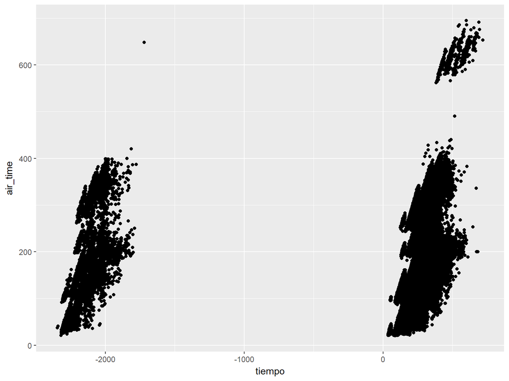

```r
ggplot(diferencias, aes(tiempo, air_time)) +
  geom_point()
```

```r
# 4 ¿Qué esperabas encontrar?
# Tiempos similares, no se estan considerando fecha, horas minutos

# 5 ¿Hay algo que arreglar?
# Del time_hour + dep_delay + air_time

mutate(flights,
       time_hour_arr = time_hour + lubridate::minutes(dep_delay + air_time),
       tiempo = time_hour_arr - time_hour) %>%
  select(time_hour, time_hour_arr, air_time, tiempo)
```

```
## # A tibble: 336,776 x 4
##    time_hour           time_hour_arr       air_time tiempo
##    <dttm>              <dttm>                 <dbl> <time>
##  1 2013-01-01 05:00:00 2013-01-01 08:49:00    227   229
##  2 2013-01-01 05:00:00 2013-01-01 08:51:00    227   231
##  3 2013-01-01 05:00:00 2013-01-01 07:42:00    160   162
##  4 2013-01-01 05:00:00 2013-01-01 08:02:00    183   182
##  5 2013-01-01 06:00:00 2013-01-01 07:50:00    116   110
##  6 2013-01-01 05:00:00 2013-01-01 07:26:00    150   146
##  7 2013-01-01 06:00:00 2013-01-01 08:33:00    158   153
##  8 2013-01-01 06:00:00 2013-01-01 06:50:00     53.0 50
##  9 2013-01-01 06:00:00 2013-01-01 08:17:00    140   137
## 10 2013-01-01 06:00:00 2013-01-01 08:16:00    138   136
## # ... with 336,766 more rows
```

# mutate en esteroides: funciones ventana

Hay muchas funciones auxiliares dentro de `dplyr` que te permiten aprovechar más al verbo `mutate`. Por ejemplo, tiene implementado varias funciones ventana:

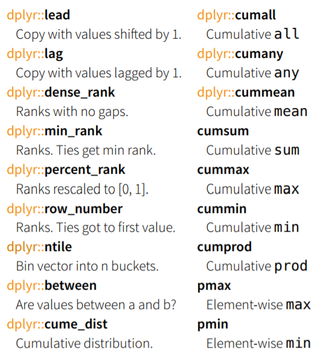

Estas funciones son mucho más útiles en *grupos* (ahí viene).

Fuente: [Data wrangling cheatsheet](https://www.rstudio.com/wp-content/uploads/2015/02/data-wrangling-cheatsheet.pdf)

# summarise

Permite colapsar un data frame en una única fila “resumen”

```r
dplyr::summarise(flights, delay = mean(dep_delay, na.rm = TRUE))
```

```
## # A tibble: 1 x 1
##   delay
##   <dbl>
## 1  12.6
```

# summarise: ejercicio

Utiliza la función `summarise` para calcular la media de las variables `date`, `dep_delay`, `arr_delay`.

# summarise_if

El ejercicio anterior es engorroso. Podemos simplificarlo.

Podemos especificar una función a aplicar a variables específicas en un dataframe. Por ejemplo, extraer la media para las variables numéricas.

```r
summarise_if(flights, is.numeric, mean, na.rm = TRUE)
```

```
## # A tibble: 1 x 14
##    year month   day dep_time sched_dep_time dep_delay arr_time
##   <dbl> <dbl> <dbl>    <dbl>          <dbl>     <dbl>    <dbl>
## 1  2013  6.55  15.7    1349.          1344.      12.6    1502.
## # ... with 7 more variables: sched_arr_time <dbl>, arr_delay <dbl>,
## #   flight <dbl>, air_time <dbl>, distance <dbl>, hour <dbl>, minute <dbl>
```

# summarise en esteroides: funciones de agregación

También se encuentran implementadas funciones de agregaciones muy comunes:

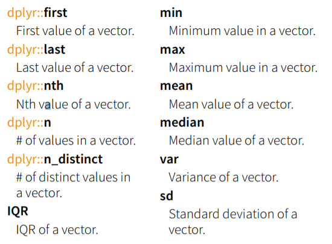

Fuente: [Data wrangling cheatsheet](https://www.rstudio.com/wp-content/uploads/2015/02/data-wrangling-cheatsheet.pdf)

# group_by

Igual que `mutate`, `summarise` es mucho más útil si se piensa en el contexto de grupos, para lo que nos sirve la función `group_by`.

```r
flights_agrupada <- group_by(flights, year, month, day)
class(flights_agrupada)
```

```
## [1] "grouped_df" "tbl_df"     "tbl"        "data.frame"
```

```r
flights_agrupada
```

```
## # A tibble: 336,776 x 19
## # Groups:   year, month, day [365]
##     year month   day dep_time sched_dep_time dep_delay arr_time
##    <int> <int> <int>    <int>          <int>     <dbl>    <int>
##  1  2013     1     1      517            515         2      830
##  2  2013     1     1      533            529         4      850
##  3  2013     1     1      542            540         2      923
##  4  2013     1     1      544            545        -1     1004
##  5  2013     1     1      554            600        -6      812
##  6  2013     1     1      554            558        -4      740
##  7  2013     1     1      555            600        -5      913
##  8  2013     1     1      557            600        -3      709
##  9  2013     1     1      557            600        -3      838
## 10  2013     1     1      558            600        -2      753
## # ... with 336,766 more rows, and 12 more variables: sched_arr_time <int>,
## #   arr_delay <dbl>, carrier <chr>, flight <int>, tailnum <chr>,
## #   origin <chr>, dest <chr>, air_time <dbl>, distance <dbl>, hour <dbl>,
## #   minute <dbl>, time_hour <dttm>
```

Ahora si, puedo generar resumenes útiles por día. Por ejemplo, el retraso promedio por día:

```r
dplyr::summarise(flights_agrupada, delay = mean(dep_delay, na.rm = TRUE))
```

```
## # A tibble: 365 x 4
## # Groups:   year, month [12]
##     year month   day delay
##    <int> <int> <int> <dbl>
##  1  2013     1     1 11.5
##  2  2013     1     2 13.9
##  3  2013     1     3 11.0
##  4  2013     1     4  8.95
##  5  2013     1     5  5.73
##  6  2013     1     6  7.15
##  7  2013     1     7  5.42
##  8  2013     1     8  2.55
##  9  2013     1     9  2.28
## 10  2013     1    10  2.84
## # ... with 355 more rows
```

# Los verbos y el group_by

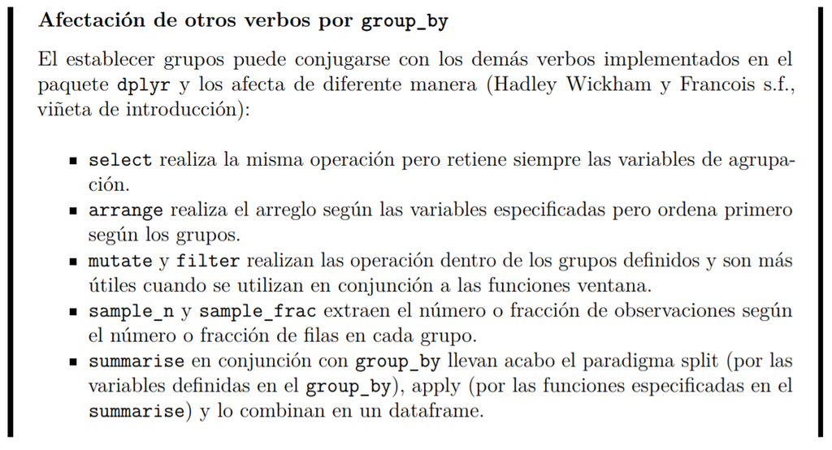

# group_by: ejercicios

- Utiliza la función `top_n`, junto con `group_by`, `arrange` y `summarise` para extraer los 10 aviones por aerolínea con el menor promedio de velocidad.
- ¿Cuáles son los aeropuertos con mayor promedio de retraso en la salida?
- ¿Cuáles son los aeropuertos con mayor promedio de retraso en las llegadas?

# group_by: ejercicios / Respuestas

```r
#1
# 10 aviones mas lentos por carrier
mutate(flights, velocidad = distance/air_time) %>%
    group_by(carrier) %>%
    arrange(velocidad) %>%
    top_n(-10) %>%
    select(tailnum, carrier, velocidad) %>%
    ungroup() %>%
    arrange(carrier, velocidad) %>%
    head(20)
```

```
## # A tibble: 20 x 3
##    tailnum carrier velocidad
##    <chr>   <chr>       <dbl>
##  1 N8932C  9E           1.54
##  2 N832AY  9E           1.59
##  3 N8631E  9E           1.71
##  4 N8598B  9E           1.74
##  5 N8790A  9E           1.88
##  6 N8623A  9E           1.88
##  7 N8970D  9E           1.88
##  8 N8944B  9E           1.96
##  9 N839AY  9E           1.96
## 10 N8554A  9E           1.96
## 11 N8543F  9E           1.96
## 12 N3FKAA  AA           1.95
## 13 N3DRAA  AA           2.17
## 14 N3FEAA  AA           2.34
## 15 N3FJAA  AA           2.46
## 16 N3GWAA  AA           2.79
## 17 N3ARAA  AA           2.97
## 18 N3GCAA  AA           3.02
## 19 N3BCAA  AA           3.17
## 20 N3DLAA  AA           3.17
```

```r
#2 aeropuerto con mayor promedio de retraso de salida
group_by(flights, origin) %>%
  dplyr::summarise(dep_delay = mean(dep_delay, na.rm = T)) %>%
  arrange(desc(dep_delay))
```

```
## # A tibble: 3 x 2
##   origin dep_delay
##   <chr>      <dbl>
## 1 EWR         15.1
## 2 JFK         12.1
## 3 LGA         10.3
```

```r
#3 aeropuerto con mayor promedio de retraso de llegada
group_by(flights, dest) %>%
  dplyr::summarise(arr_delay = mean(arr_delay, na.rm = T)) %>%
  arrange(desc(arr_delay))
```

```
## # A tibble: 105 x 2
##    dest  arr_delay
##    <chr>     <dbl>
##  1 CAE        41.8
##  2 TUL        33.7
##  3 OKC        30.6
##  4 JAC        28.1
##  5 TYS        24.1
##  6 MSN        20.2
##  7 RIC        20.1
##  8 CAK        19.7
##  9 DSM        19.0
## 10 GRR        18.2
## # ... with 95 more rows
```

# %>%

Un verbo solo no es demasiado útil. Lo poderoso de los verbos es utilizarlos en conjunto. Para ello, ayuda mucho utilizar el operador *pipe*.

Por ejemplo, puedo encontrar los peores días en retrasos.

```r
select(flights,
  year:day,
  ends_with("delay"),
  distance,
  air_time
) %>%
  mutate(
  gain = arr_delay - dep_delay,
  speed = distance / air_time * 60
) %>%
  group_by(year, month, day) %>%
  filter(rank(desc(arr_delay)) < 10)
```

```
## # A tibble: 3,306 x 9
## # Groups:   year, month, day [365]
##     year month   day dep_delay arr_delay distance air_time  gain speed
##    <int> <int> <int>     <dbl>     <dbl>    <dbl>    <dbl> <dbl> <dbl>
##  1  2013     1     1       853       851      184       41    -2  269.
##  2  2013     1     1       290       338     1134      213    48  319.
##  3  2013     1     1       260       263      266       46     3  347.
##  4  2013     1     1       157       174      213       60    17  213
##  5  2013     1     1       216       222      708      121     6  351.
##  6  2013     1     1       255       250      589      115    -5  307.
##  7  2013     1     1       285       246     1085      146   -39  446.
##  8  2013     1     1       192       191      199       44    -1  271.
##  9  2013     1     1       379       456     1092      222    77  295.
## 10  2013     1     2       224       207      550       94   -17  351.
## # ... with 3,296 more rows
```

o los destinos más populares

```r
flights %>%
  group_by(dest) %>%
  filter(n() > 365)
```

```
## # A tibble: 332,577 x 19
## # Groups:   dest [77]
##     year month   day dep_time sched_dep_time dep_delay arr_time
##    <int> <int> <int>    <int>          <int>     <dbl>    <int>
##  1  2013     1     1      517            515         2      830
##  2  2013     1     1      533            529         4      850
##  3  2013     1     1      542            540         2      923
##  4  2013     1     1      544            545        -1     1004
##  5  2013     1     1      554            600        -6      812
##  6  2013     1     1      554            558        -4      740
##  7  2013     1     1      555            600        -5      913
##  8  2013     1     1      557            600        -3      709
##  9  2013     1     1      557            600        -3      838
## 10  2013     1     1      558            600        -2      753
## # ... with 332,567 more rows, and 12 more variables: sched_arr_time <int>,
## #   arr_delay <dbl>, carrier <chr>, flight <int>, tailnum <chr>,
## #   origin <chr>, dest <chr>, air_time <dbl>, distance <dbl>, hour <dbl>,
## #   minute <dbl>, time_hour <dttm>
```

# %>%: ejercicios

1. ¿Cuál es la hora óptima para viajar para evitar retrasos?
2. Encuentra todos los destinos que vuelan por más de una aerolínea. ¿Cuál es la mejor aerolínea en ese subgrupo?

# %>%: ejercicios / Respuestas

```r
# 1. ¿Cuál es la hora óptima para viajar para evitar retrasos?
flights %>%
  group_by(hour) %>%
  dplyr::summarise(dep_delay = mean(dep_delay, na.rm = T)) %>%
  arrange(dep_delay)
```

```
## # A tibble: 20 x 2
##     hour dep_delay
##    <dbl>     <dbl>
##  1     5     0.688
##  2     6     1.64
##  3     7     1.91
##  4     8     4.13
##  5     9     4.58
##  6    10     6.50
##  7    11     7.19
##  8    12     8.61
##  9    13    11.4
## 10    14    13.8
## 11    23    14.0
## 12    15    16.9
## 13    16    18.8
## 14    22    18.8
## 15    17    21.1
## 16    18    21.1
## 17    21    24.2
## 18    20    24.3
## 19    19    24.8
## 20     1   NaN
```

```r
# 2. Encuentra todos los destinos que vuelan por más de una aerolínea. ¿Cuál es la mejor aerolínea en ese subgrupo?
flights %>%
  group_by(dest, carrier) %>%
  dplyr::summarise(
    air_time = mean(air_time, na.rm = T)
  ) %>%
  ungroup() %>%
  group_by(dest) %>%
  mutate(n = n()) %>%
  filter(n > 1) %>%
  arrange(dest, air_time) %>%
  top_n(-1, wt = air_time)
```

```
## # A tibble: 76 x 4
## # Groups:   dest [76]
##    dest  carrier air_time     n
##    <chr> <chr>      <dbl> <int>
##  1 ATL   DL         112.      7
##  2 AUS   WN         211.      6
##  3 AVL   EV          89.8     2
##  4 BDL   EV          25.5     2
##  5 BGR   EV          54.1     2
##  6 BNA   WN         114.      5
##  7 BOS   US          37.9     7
##  8 BQN   B6         194.      2
##  9 BTV   EV          45.6     3
## 10 BUF   EV          51.1     4
## # ... with 66 more rows
```

# joins: preliminares

- ¿Qué pasa si lo que quiero es saber cómo se ven afectados los retrasos por el clima?
- ¿O como afecta el tipo de avión y su edad a la velocidad promedio?
- ¿O si hay aeropuertos que están muy saturados e, independientemente del clima o el destino, siempre tienen retrasos?

Para ello, debo juntar información de otras de las bases que están en el paquete `nycflights13`.

# joins: preliminares

Recordemos las tablas en el paquete:

```r
data(package = "nycflights13")
```

El modelo de relación de las tablas se ve como sigue:

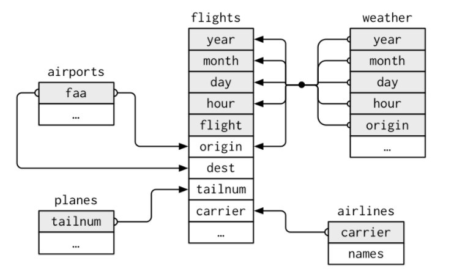

# joins: SQL

Podemos pensar en los joins que se realizan en SQL>

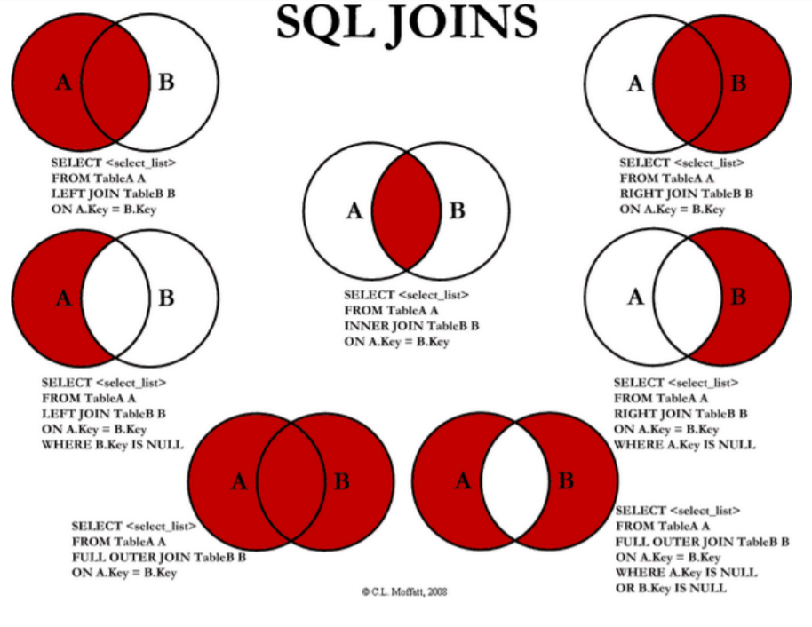

# joins: dplyr

Y entender cómo se traducen en dplyr:

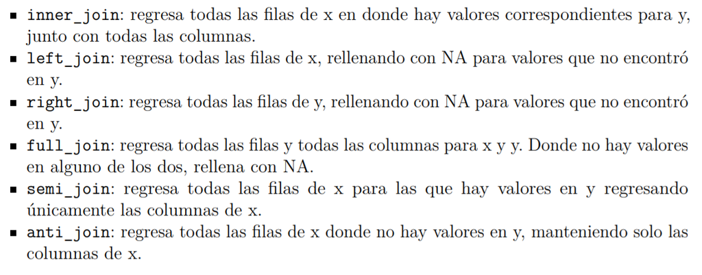

# joins: ejemplo sencillo

Ahora, supongamos que queremos saber la velocidad promedio de los aviones que tenemos en nuestros datos para todos sus vuelos.

```r
# base de aviones con velocidad
library(nycflights13)
vel_aviones <- flights %>%
  group_by(tailnum) %>% # identificador de avion
  dplyr::summarise(vel_prom = mean(distance/air_time, na.rm = T))

inner_join(
  planes,
  vel_aviones
)  %>%
  select(tailnum, year, vel_prom) %>%
  arrange(desc(vel_prom))
```

```
## # A tibble: 3,322 x 3
##    tailnum  year vel_prom
##    <chr>   <int>    <dbl>
##  1 N228UA   2002     8.35
##  2 N315AS   2002     8.31
##  3 N654UA   1992     8.31
##  4 N819AW   2000     8.17
##  5 N382HA   2010     8.09
##  6 N388HA   2012     8.07
##  7 N391HA   2013     8.07
##  8 N777UA   1995     8.06
##  9 N385HA   2012     8.05
## 10 N392HA   2013     8.04
## # ... with 3,312 more rows
```

Ahora, queremos saber los destinos con mayores retrasos.

```r
destinos <- flights %>%
  group_by(dest) %>%
  dplyr::summarise(retraso = mean(arr_delay, na.rm = T))

inner_join(
  airports,
  destinos,
  by = c("faa" = "dest")
) %>%
  arrange(desc(retraso))
```

```
## # A tibble: 101 x 9
##    faa   name               lat    lon   alt    tz dst   tzone      retraso
##    <chr> <chr>            <dbl>  <dbl> <dbl> <dbl> <chr> <chr>        <dbl>
##  1 CAE   Columbia Metrop~  33.9  -81.1   236    -5 A     America/N~    41.8
##  2 TUL   Tulsa Intl        36.2  -95.9   677    -6 A     America/C~    33.7
##  3 OKC   Will Rogers Wor~  35.4  -97.6  1295    -6 A     America/C~    30.6
##  4 JAC   Jackson Hole Ai~  43.6 -111.   6451    -7 A     America/D~    28.1
##  5 TYS   Mc Ghee Tyson     35.8  -84.0   981    -5 A     America/N~    24.1
##  6 MSN   Dane Co Rgnl Tr~  43.1  -89.3   887    -6 A     America/C~    20.2
##  7 RIC   Richmond Intl     37.5  -77.3   167    -5 A     America/N~    20.1
##  8 CAK   Akron Canton Re~  40.9  -81.4  1228    -5 A     America/N~    19.7
##  9 DSM   Des Moines Intl   41.5  -93.7   958    -6 A     America/C~    19.0
## 10 GRR   Gerald R Ford I~  42.9  -85.5   794    -5 A     America/N~    18.2
## # ... with 91 more rows
```

# joins: ejemplo con graficación

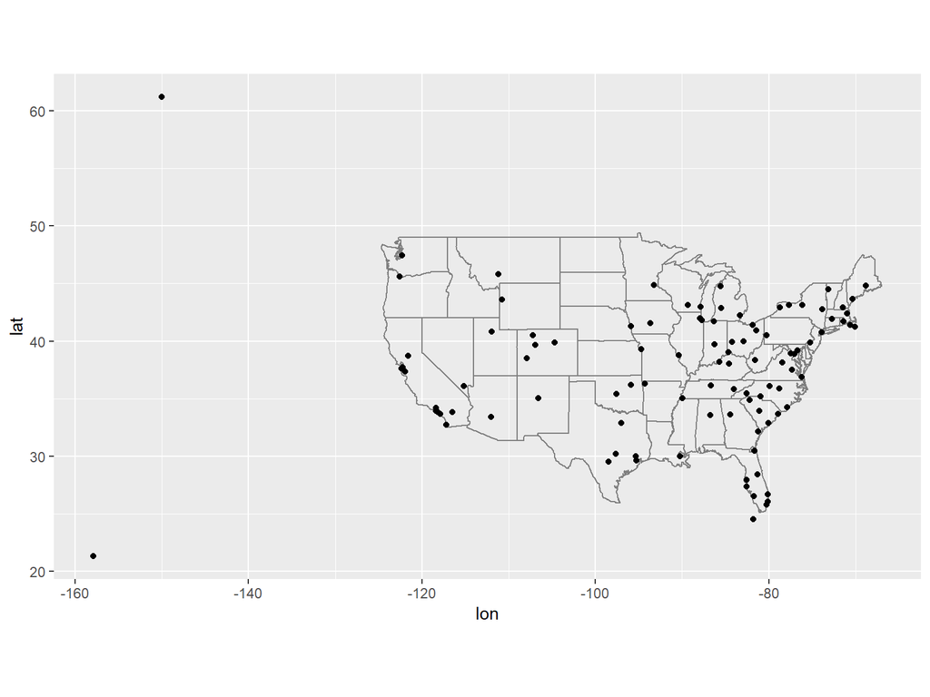

```r
airports %>%
  semi_join(flights, c("faa" = "dest")) %>%
  ggplot(aes(lon, lat)) +
    borders("state") +
    geom_point() +
    coord_quickmap()
```

Para más ejemplos como estos, revisa el capítulo de “[Relational data](http://r4ds.had.co.nz/relational-data.html)” en *R for data science*.

# joins: ejercicios

1. ¿Cuáles son los aeropuertos que SI están en la base de destinos?
2. ¿Cuáles son los aeropuertos que NO están en la base de destinos?
3. Realiza un resumen de los vuelos por aeropuerto para varias variables con la función `summarise`.
4. Utiliza la función `inner_join` para pegar la tablas de resumen creada en el paso anterior a la tabla `airports`
5. Realiza un resumen de los vuelos por avión para varias variables con la función `summarise`.
6. Utiliza la función `left_join` para pegar la tablas de resumen creada en el paso anterior a la tabla `planes`
7. Extrae el porcentaje de vuelos cancelados por aerolínea cada año y el porcentaje de vuelos retrasados por aerolínea cada año.

# joins: ejercicios / Respuestas

```r
# 1 ¿Cuáles son los aeropuertos que SI están en la base de destinos?
semi_join(airports, flights, by = c("faa" = "dest"))
```

```
## # A tibble: 101 x 8
##    faa   name                     lat    lon   alt    tz dst   tzone
##    <chr> <chr>                  <dbl>  <dbl> <dbl> <dbl> <chr> <chr>
##  1 ABQ   Albuquerque Internati~  35.0 -107.   5355    -7 A     America/Den~
##  2 ACK   Nantucket Mem           41.3  -70.1    48    -5 A     America/New~
##  3 ALB   Albany Intl             42.7  -73.8   285    -5 A     America/New~
##  4 ANC   Ted Stevens Anchorage~  61.2 -150.    152    -9 A     America/Anc~
##  5 ATL   Hartsfield Jackson At~  33.6  -84.4  1026    -5 A     America/New~
##  6 AUS   Austin Bergstrom Intl   30.2  -97.7   542    -6 A     America/Chi~
##  7 AVL   Asheville Regional Ai~  35.4  -82.5  2165    -5 A     America/New~
##  8 BDL   Bradley Intl            41.9  -72.7   173    -5 A     America/New~
##  9 BGR   Bangor Intl             44.8  -68.8   192    -5 A     America/New~
## 10 BHM   Birmingham Intl         33.6  -86.8   644    -6 A     America/Chi~
## # ... with 91 more rows
```

```r
# 2 ¿Cuáles son los aeropuertos que NO están en la base de destinos?
anti_join(airports, flights, by = c("faa" = "dest"))
```

```
## # A tibble: 1,357 x 8
##    faa   name                    lat    lon   alt    tz dst   tzone
##    <chr> <chr>                 <dbl>  <dbl> <dbl> <dbl> <chr> <chr>
##  1 04G   Lansdowne Airport      41.1  -80.6  1044    -5 A     America/New_~
##  2 06A   Moton Field Municipa~  32.5  -85.7   264    -6 A     America/Chic~
##  3 06C   Schaumburg Regional    42.0  -88.1   801    -6 A     America/Chic~
##  4 06N   Randall Airport        41.4  -74.4   523    -5 A     America/New_~
##  5 09J   Jekyll Island Airport  31.1  -81.4    11    -5 A     America/New_~
##  6 0A9   Elizabethton Municip~  36.4  -82.2  1593    -5 A     America/New_~
##  7 0G6   Williams County Airp~  41.5  -84.5   730    -5 A     America/New_~
##  8 0G7   Finger Lakes Regiona~  42.9  -76.8   492    -5 A     America/New_~
##  9 0P2   Shoestring Aviation ~  39.8  -76.6  1000    -5 U     America/New_~
## 10 0S9   Jefferson County Intl  48.1 -123.    108    -8 A     America/Los_~
## # ... with 1,347 more rows
```

```r
# 3 Realiza un resumen de los vuelos por aeropuerto para varias variables con la función `summarise`.
res.vuelos <- flights %>%
  group_by(dest) %>%
  dplyr::summarise(
    flights = n()
    , planes = n_distinct(tailnum)
    , carriers = n_distinct(carrier)
    , dep_delay_mean = mean(dep_delay, na.rm = T)
  )

# 4 Utiliza la función `inner_join` para pegar la tablas de resumen creada en el paso anterior a la tabla `airports`
airports_flights <- inner_join(airports, res.vuelos
                               , by = c("faa" = "dest"))

# 5 Realiza un resumen de los vuelos por avión para varias variables con la función `summarise`.
res.aviones <- flights %>%
  group_by(tailnum) %>%
  dplyr::summarise(
    flights = n()
    , carriers = n_distinct(carrier)
    , dep_delay_mean = mean(dep_delay, na.rm = T)
    , arr_delay_mean = mean(arr_delay, na.rm = T)
    , dist_mean = mean(distance, na.rm = T)
    , vel_mean = mean(distance/air_time, na.rm = T)
  )

# 6 Utiliza la función `left_join` para pegar la tablas de resumen creada en el paso anterior a la tabla `planes`
planes_flights <- left_join(planes, res.aviones)

# 7 Extrae el porcentaje de vuelos cancelados por aerolínea cada año y el porcentaje de vuelos retrasados por aerolínea cada año.
flights %>%
  mutate(
    cancelled = ifelse(is.na(dep_time), T, F),
    anio = lubridate::year(time_hour)) %>%
  group_by(carrier, anio) %>%
  dplyr::summarise(
    vuelos.anuales = n()
    , cancelados = sum(cancelled, na.rm = T)/vuelos.anuales * 100
    , retrasados = sum(dep_delay > 0, na.rm = T)/vuelos.anuales * 100
  ) %>%
  ungroup()
```

```
## # A tibble: 16 x 5
##    carrier  anio vuelos.anuales cancelados retrasados
##    <chr>   <dbl>          <int>      <dbl>      <dbl>
##  1 9E       2013          18460      5.66        38.3
##  2 AA       2013          32729      1.94        31.0
##  3 AS       2013            714      0.280       31.7
##  4 B6       2013          54635      0.853       39.3
##  5 DL       2013          48110      0.725       31.7
##  6 EV       2013          54173      5.20        42.7
##  7 F9       2013            685      0.438       49.8
##  8 FL       2013           3260      2.24        50.7
##  9 HA       2013            342      0           20.2
## 10 MQ       2013          26397      4.67        30.4
## 11 OO       2013             32      9.38        28.1
## 12 UA       2013          58665      1.17        46.5
## 13 US       2013          20536      3.23        23.3
## 14 VX       2013           5162      0.601       43.1
## 15 WN       2013          12275      1.56        53.4
## 16 YV       2013            601      9.32        38.8
```

# dplyr / material adicional

- Cheatsheet https://www.rstudio.com/resources/cheatsheets/#dplyr
- Libro base de este tutorial: https://htmlpreview.github.io/?https://raw.githubusercontent.com/salimv19/ssR/master/aprendeR/transformacion-de-datos.html
- Curso de swirl Getting and cleaning data.
- Curso Cleaning Data in R de Data Camp.
- Curso Data Manipulation in R with dplyr de Data Camp.
- Curso Joining data in R with dplyr de Data Camp

# Datos limpios

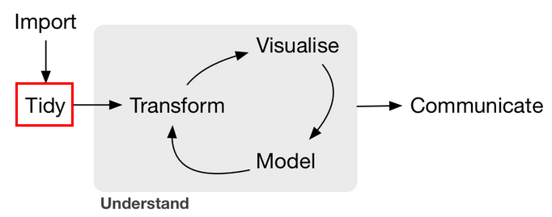

# Datos limpios

Los conjuntos de datos limpios (*tidy datasets*) permiten manipularlos facilmente, modelarlos y visualizarlos.

Los datos limpios tienen una estructura especifica:

- cada variable es una columna,
- cada observacion una fila y,
- cada tipo de unidad observacional forma una tabla

En resumen: “cada valor ocupa su propia celda”

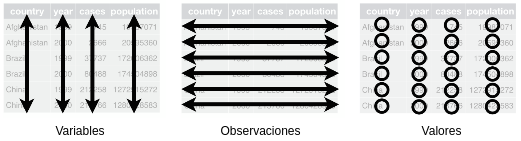

# Representaciones de los mismos datos

Pensemos en unos datos:

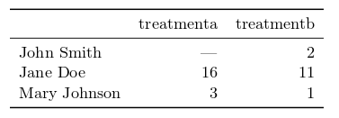

Su estructura “transpuesta”:

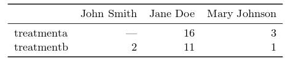

Su estructura “tidy” o “limpia”:

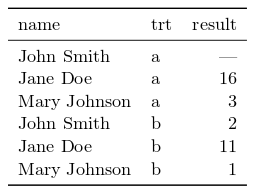

1. *persona* con tres posibles valores (John, Jane, Mary)
2. *tratamiento* con dos posibles valores (a o b)
3. *resultado* con 6 valores (-, 16, 3, 2, 11, 1)

# Datos limpios: ejercicio

- Crea un dataframe con los valores de la tabla 1 y otro con los valores de la tabla 3.
- Extrae el resultado para (John Smith, tratamiento a) en la primera configuracion y en la segunda.
- Especifica el numero de tratamientos con la forma sucia y la forma limpia.
- ¿Cual es la media de los resultados? Usa la forma 1 y la forma 2.
- Extrae los tratamientos del tipo a en la forma 2.

# Datos limpios: ejercicio 2

Este tipo de formato de datos (poner valores de variables en las columnas) es útil también cuando se capturan datos al evitar la repetición de valores.

```r
# Generación aleatoria de datos
df <- data.frame(
  sujetos = LETTERS[1:16],
  grupo = sample(c("control", "tratamiento"), size = 16, replace = T
                 , prob = c(0.5, 0.5))
  )
m <- t(sapply(runif(16, 16, 35), FUN = function(x){
  cumsum(c(x, rnorm(11, mean = 0.5, sd = 1)))
  }))
colnames(m) <- paste0("mes",1:12)
df <- cbind(df, m)

knitr::kable(df,
caption = 'Mediciones de IMC en sujetos.'
)
```

Mediciones de IMC en sujetos.

| sujetos | grupo | mes1 | mes2 | mes3 | mes4 | mes5 | mes6 | mes7 | mes8 | mes9 | mes10 | mes11 | mes12 |
| --- | --- | --- | --- | --- | --- | --- | --- | --- | --- | --- | --- | --- | --- |
| A | control | 18.60907 | 21.18175 | 22.24732 | 22.12220 | 20.60200 | 20.44384 | 21.10361 | 22.80511 | 22.21230 | 21.04176 | 20.67154 | 19.68308 |
| B | tratamiento | 32.31513 | 32.42454 | 34.13971 | 33.16996 | 32.88781 | 33.86039 | 35.33720 | 35.31383 | 35.34412 | 35.86287 | 35.80472 | 36.96907 |
| C | tratamiento | 24.65079 | 26.29956 | 28.23885 | 28.79803 | 29.05590 | 28.96469 | 30.95258 | 29.52523 | 28.20520 | 28.04535 | 28.47533 | 28.42012 |
| D | control | 18.03463 | 19.71946 | 20.42292 | 20.90995 | 21.77210 | 22.24692 | 21.65937 | 22.46086 | 25.00632 | 25.21041 | 24.20542 | 25.06809 |
| E | control | 19.89835 | 21.00169 | 23.97610 | 25.11251 | 23.11086 | 24.97335 | 26.22249 | 27.48694 | 29.18125 | 29.69090 | 31.09195 | 31.45969 |
| F | tratamiento | 34.86271 | 36.65796 | 37.05301 | 39.43004 | 42.63473 | 43.54595 | 44.17534 | 45.18180 | 45.93260 | 46.71608 | 47.70552 | 48.70497 |
| G | control | 21.75387 | 22.25818 | 21.11375 | 21.32369 | 22.95020 | 23.94006 | 24.91224 | 25.54097 | 27.42867 | 27.67252 | 26.86259 | 27.76928 |
| H | tratamiento | 23.51394 | 24.83402 | 26.61547 | 28.47281 | 29.19605 | 28.39157 | 30.47040 | 29.58855 | 30.11356 | 32.12668 | 31.54560 | 31.53578 |
| I | control | 26.20219 | 25.96919 | 27.08579 | 26.00833 | 24.83459 | 24.91545 | 26.65532 | 26.69030 | 27.85343 | 26.09601 | 26.79356 | 27.72001 |
| J | tratamiento | 22.37186 | 23.36488 | 24.66423 | 27.13352 | 27.97288 | 27.67796 | 26.95138 | 28.31300 | 28.60528 | 29.51927 | 30.18410 | 31.20735 |
| K | tratamiento | 30.06494 | 29.19191 | 29.09110 | 29.82182 | 31.19251 | 29.79146 | 29.14315 | 30.16286 | 30.75659 | 33.26832 | 34.81068 | 33.91232 |
| L | control | 25.57869 | 26.12009 | 26.35140 | 26.89228 | 26.22951 | 26.24568 | 26.99316 | 29.19530 | 29.90028 | 31.57439 | 30.37044 | 28.73028 |
| M | control | 19.34064 | 18.29226 | 18.81427 | 18.45146 | 17.16086 | 17.14111 | 18.55526 | 17.72505 | 18.25532 | 16.25270 | 16.99804 | 17.56083 |
| N | control | 20.99591 | 21.10404 | 22.56747 | 21.92493 | 22.04497 | 21.94772 | 22.05730 | 24.23532 | 23.37036 | 24.20825 | 25.63198 | 25.19422 |
| O | control | 33.82263 | 34.58942 | 34.68925 | 35.40868 | 36.67237 | 36.47063 | 36.30371 | 37.67496 | 36.70225 | 36.74829 | 36.34629 | 37.83317 |
| P | control | 18.75652 | 19.03786 | 17.51422 | 19.19386 | 18.64250 | 19.53566 | 21.70427 | 19.36587 | 20.22809 | 20.93012 | 22.62339 | 22.63860 |

Nuevamente, queremos convertir la columna 3 a 14 en filas, es decir, observaciones. Utiliza el comando `gather` para realizar esto y obtener el resultado que se muestra en la tabla

# Datos limpios: ejercicio / Respuestas

```r
# Respuesta
opcion1 <- tidyr::gather(df, key = mes, value = IMC, -sujetos, -grupo)
opcion2 <- tidyr::gather(df, key = mes, value = IMC, mes1:mes12)
knitr::kable(sample_n(opcion2, size = 10), booktabs = TRUE,
caption = 'Muestra de datos limpios para experimentos IMC.'
)
```

Muestra de datos limpios para experimentos IMC.

| sujetos | grupo | mes | IMC |
| --- | --- | --- | --- |
| P | control | mes11 | 22.62339 |
| E | control | mes9 | 29.18125 |
| B | tratamiento | mes11 | 35.80472 |
| N | control | mes4 | 21.92493 |
| H | tratamiento | mes11 | 31.54560 |
| F | tratamiento | mes3 | 37.05301 |
| H | tratamiento | mes12 | 31.53578 |
| M | control | mes11 | 16.99804 |
| H | tratamiento | mes6 | 28.39157 |
| J | tratamiento | mes2 | 23.36488 |

# De sucio a limpio

5 problemas comunes:

1. Los nombres de las columnas son valores, no nombres de variables.
2. Múltiples variables se encuentran en la misma columna.
3. Las variables están guardadas tanto en filas como en columnas.
4. Muchos tipos de unidad observacional se encuentran en la misma tabla.
5. Una sola unidad observacional se guarda en varias tablas.

# Los nombres de las columnas son valores, no nombres de variables

Datos sucios

```r
raw <- filter(who, country == "Mexico", year >= 2000, year < 2011) %>%
  select(., country, year, contains("sp_m"))
raw
```

```
## # A tibble: 11 x 9
##    country  year new_sp_m014 new_sp_m1524 new_sp_m2534 new_sp_m3544
##    <chr>   <int>       <int>        <int>        <int>        <int>
##  1 Mexico   2000         214         1079         1387         1162
##  2 Mexico   2001         130         1448         1639         1683
##  3 Mexico   2002         154         1090         1292         1301
##  4 Mexico   2003         187         1207         1461         1417
##  5 Mexico   2004          86         1053         1276         1181
##  6 Mexico   2005         100         1095         1376         1314
##  7 Mexico   2006         129          986         1320         1333
##  8 Mexico   2007         145          981         1286         1286
##  9 Mexico   2008         124          966         1292         1314
## 10 Mexico   2009         103         1030         1262         1401
## 11 Mexico   2010         125         1081         1375         1380
## # ... with 3 more variables: new_sp_m4554 <int>, new_sp_m5564 <int>,
## #   new_sp_m65 <int>
```

Primer paso de limpieza: pasamos los nombres de columnas, a filas (como valores de variables).

```r
junta <- tidyr::gather(who, key = variables, value = casos
                       , -country, -iso2, -iso3, -year, na.rm = T)
junta
```

```
## # A tibble: 76,046 x 6
##    country     iso2  iso3   year variables   casos
##    <chr>       <chr> <chr> <int> <chr>       <int>
##  1 Afghanistan AF    AFG    1997 new_sp_m014     0
##  2 Afghanistan AF    AFG    1998 new_sp_m014    30
##  3 Afghanistan AF    AFG    1999 new_sp_m014     8
##  4 Afghanistan AF    AFG    2000 new_sp_m014    52
##  5 Afghanistan AF    AFG    2001 new_sp_m014   129
##  6 Afghanistan AF    AFG    2002 new_sp_m014    90
##  7 Afghanistan AF    AFG    2003 new_sp_m014   127
##  8 Afghanistan AF    AFG    2004 new_sp_m014   139
##  9 Afghanistan AF    AFG    2005 new_sp_m014   151
## 10 Afghanistan AF    AFG    2006 new_sp_m014   193
## # ... with 76,036 more rows
```

La operación realizada se representa:

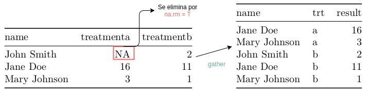

# Múltiples variables se encuentran en la misma columna

Los datos “juntados” anteriormente, ahora los limpiamos, separando las columnas en distintas variables.

```r
limpios <- junta %>%
  mutate(variables = gsub("new_|new", "", variables)) %>%
  tidyr::extract(., col = variables
          , into = c("diagnostico", "genero", "edad")
          , regex = "([[:alnum:]]+)_([a-z])([[0-9]]+)")

limpios
```

```
## # A tibble: 76,046 x 8
##    country     iso2  iso3   year diagnostico genero edad  casos
##    <chr>       <chr> <chr> <int> <chr>       <chr>  <chr> <int>
##  1 Afghanistan AF    AFG    1997 sp          m      014       0
##  2 Afghanistan AF    AFG    1998 sp          m      014      30
##  3 Afghanistan AF    AFG    1999 sp          m      014       8
##  4 Afghanistan AF    AFG    2000 sp          m      014      52
##  5 Afghanistan AF    AFG    2001 sp          m      014     129
##  6 Afghanistan AF    AFG    2002 sp          m      014      90
##  7 Afghanistan AF    AFG    2003 sp          m      014     127
##  8 Afghanistan AF    AFG    2004 sp          m      014     139
##  9 Afghanistan AF    AFG    2005 sp          m      014     151
## 10 Afghanistan AF    AFG    2006 sp          m      014     193
## # ... with 76,036 more rows
```

Limpiamos las categorias de edad

```r
limpios %>%
  mutate(
    edad = factor(edad,
                  levels = c("014", "1524", "2534", "3544"
                             , "4554", "5564", "65")
                  , labels = c("0-14", "15-24", "25-34", "35-44"
                               , "45-54", "55-64", "65>")
                  , ordered = T)
  )
```

```
## # A tibble: 76,046 x 8
##    country     iso2  iso3   year diagnostico genero edad  casos
##    <chr>       <chr> <chr> <int> <chr>       <chr>  <ord> <int>
##  1 Afghanistan AF    AFG    1997 sp          m      0-14      0
##  2 Afghanistan AF    AFG    1998 sp          m      0-14     30
##  3 Afghanistan AF    AFG    1999 sp          m      0-14      8
##  4 Afghanistan AF    AFG    2000 sp          m      0-14     52
##  5 Afghanistan AF    AFG    2001 sp          m      0-14    129
##  6 Afghanistan AF    AFG    2002 sp          m      0-14     90
##  7 Afghanistan AF    AFG    2003 sp          m      0-14    127
##  8 Afghanistan AF    AFG    2004 sp          m      0-14    139
##  9 Afghanistan AF    AFG    2005 sp          m      0-14    151
## 10 Afghanistan AF    AFG    2006 sp          m      0-14    193
## # ... with 76,036 more rows
```

Esta forma es limpia pues cada columna es una variable, cada fila es una observación y no se mezclan unidades observacionales.

# gather: ejercicio

A continuación se crea el dataframe *pob* que contiene un identificador para el individuo (id) y una columna llamada *variables* que contiene el sexo, año de nacimiento y la altura en centímetros todos en una columna y separados por _

Utiliza la función *separate* del paquete *tidyr* para limpiar estos datos.

```r
# Respuestas
# Generamos los datos
pob <- tibble(
  id = 1:1000
  , variables = paste0(
    sample(x = c('f', 'm'), size = 1000, replace = T)
    , "_"
    , floor(runif(1000, 45, 99))
    , "_"
    , floor(runif(1000, 50, 190))
  )
)


## Tu respuesta>
```

# gather: ejercicio / Respuesta

```r
# Respuestas
# Generamos los datos
pob <- tibble(
  id = 1:1000
  , variables = paste0(
    sample(x = c('f', 'm'), size = 1000, replace = T)
    , "_"
    , floor(runif(1000, 45, 99))
    , "_"
    , floor(runif(1000, 50, 190))
  )
)
# Utilizamos separate para generar las variables:
# sexo, año de nacimiento y altura
pob.tidy <- pob %>%
  separate(col = variables
           , into = c("sexo", "anio_nac", "altura"), sep = "_")

# Pasamos a enteros las variables anio de nac y altura
pob.tidy %>%
  mutate_each(funs(as.integer), anio_nac, altura)
```

```
## # A tibble: 1,000 x 4
##       id sexo  anio_nac altura
##    <int> <chr>    <int>  <int>
##  1     1 f           82     86
##  2     2 f           74    175
##  3     3 f           91    100
##  4     4 f           74    120
##  5     5 m           77    103
##  6     6 m           56     93
##  7     7 f           76    145
##  8     8 m           93    104
##  9     9 m           83    114
## 10    10 m           45     52
## # ... with 990 more rows
```

# Las variables están guardadas tanto en filas como en columnas

Datos sucios: mediciones de temperatura mínima y máxima, para distintos días del mes.

```
##         id year month element d1   d2   d3 d4   d5 d6
## 1  MX17004 2010     1    tmax NA   NA   NA NA   NA NA
## 2  MX17004 2010     1    tmin NA   NA   NA NA   NA NA
## 3  MX17004 2010     2    tmax NA 27.3 24.1 NA   NA NA
## 4  MX17004 2010     2    tmin NA 14.4 14.4 NA   NA NA
## 5  MX17004 2010     3    tmax NA   NA   NA NA 32.1 NA
## 6  MX17004 2010     3    tmin NA   NA   NA NA 14.2 NA
## 7  MX17004 2010     4    tmax NA   NA   NA NA   NA NA
## 8  MX17004 2010     4    tmin NA   NA   NA NA   NA NA
## 9  MX17004 2010     5    tmax NA   NA   NA NA   NA NA
## 10 MX17004 2010     5    tmin NA   NA   NA NA   NA NA
```

Para limpiar, lo primero que debemos hacer es juntar los días (que son valores de la variable día) en una sola columna. Después utilizamos la nueva variable para crear la fecha.

```r
# Tidy
# Primero, juntamos la variable dias
clean1 <- tidyr::gather(raw, key = variable, value = value, d1:d31
                        , na.rm = T)

# Después, generamos la variable día y fecha
clean1$day <- as.integer(str_replace(clean1$variable, "d", ""))
clean1$date <- as.Date(ISOdate(clean1$year, clean1$month, clean1$day))

# Seleccionamos las variables limpias y ordenamos
clean1 <- dplyr::select_(clean1, "id", "date", "element", "value") %>%
  dplyr::arrange(date, element)

head(clean1, 10)
```

```
##         id       date element value
## 1  MX17004 2010-01-30    tmax  27.8
## 2  MX17004 2010-01-30    tmin  14.5
## 3  MX17004 2010-02-02    tmax  27.3
## 4  MX17004 2010-02-02    tmin  14.4
## 5  MX17004 2010-02-03    tmax  24.1
## 6  MX17004 2010-02-03    tmin  14.4
## 7  MX17004 2010-02-11    tmax  29.7
## 8  MX17004 2010-02-11    tmin  13.4
## 9  MX17004 2010-02-23    tmax  29.9
## 10 MX17004 2010-02-23    tmin  10.7
```

El segundo paso es transformar la variable `element` en dos columnas pues, en realidad, almacena dos variables: temperatura máxima y mínima.

```r
# Las temperaturas van a columnas
clean2 <- tidyr::spread(clean1, key = element, value = value)
head(clean2, 10)
```

```
##         id       date tmax tmin
## 1  MX17004 2010-01-30 27.8 14.5
## 2  MX17004 2010-02-02 27.3 14.4
## 3  MX17004 2010-02-03 24.1 14.4
## 4  MX17004 2010-02-11 29.7 13.4
## 5  MX17004 2010-02-23 29.9 10.7
## 6  MX17004 2010-03-05 32.1 14.2
## 7  MX17004 2010-03-10 34.5 16.8
## 8  MX17004 2010-03-16 31.1 17.6
## 9  MX17004 2010-04-27 36.3 16.7
## 10 MX17004 2010-05-27 33.2 18.2
```

En este caso, se utilizó la función `spread` del paquete `tidyr`. Esta función realiza una especie de inverso a la operación que hace `gather`. En lugar de juntar nombres de variables, utiliza los valores de una variable como nombres de columnas (parámetro *key*) y rellena apropiadamente las celdas con los valores de otra variable (parámetro *value*).

# Muchos tipos de unidad observacional se encuentran en la misma tabla

En ocasiones las bases de datos involucran diferentes tipos de unidad observacional. Para tener datos limpios, cada unidad observacional debe estar almacenada en su propia tabla.

Para este ejemplo, utilizamos la base de datos `billboard`

```r
rm(list = ls())
billboard <- readr::read_csv("tidyr_datasets/billboard.csv")
billboard_long <- gather(billboard, week, rank, x1st.week:x76th.week
                         , na.rm = TRUE)
billboard_tidy <- billboard_long %>%
  mutate(
    week = parse_number(week),
    date = as.Date(date.entered) + 7 * (week - 1)) %>%
    select(-date.entered)
head(billboard_tidy)
```

```
## # A tibble: 6 x 9
##    year artist.inverted track time  genre date.peaked  week  rank
##   <dbl> <chr>           <chr> <tim> <chr> <date>      <dbl> <dbl>
## 1  2000 Destiny's Child Inde~ 03:38 Rock  2000-11-18      1    78
## 2  2000 Santana         Mari~ 04:18 Rock  2000-04-08      1    15
## 3  2000 Savage Garden   I Kn~ 04:07 Rock  2000-01-29      1    71
## 4  2000 Madonna         Music 03:45 Rock  2000-09-16      1    41
## 5  2000 Aguilera, Chri~ Come~ 03:38 Rock  2000-10-14      1    57
## 6  2000 Janet           Does~ 04:17 Rock  2000-08-26      1    59
## # ... with 1 more variable: date <date>
```

Debemos separar las unidades observacionales, esto significa separar la base de datos en dos: la tabla *canciones* que almacena artista, nombre de la canción y duración; la tabla *posiciones* que almacena el ranking de la canción en cada semana.

```r
canciones <- billboard_tidy %>%
  select(artist.inverted, track, year, time) %>%
  unique() %>%
  arrange(artist.inverted) %>%
  mutate(song_id = row_number(artist.inverted))

head(canciones, 5)
```

```
## # A tibble: 5 x 5
##   artist.inverted track                                  year time  song_id
##   <chr>           <chr>                                 <dbl> <tim>   <int>
## 1 2 Pac           Baby Don't Cry (Keep Ya Head Up II)    2000 04:22       1
## 2 2Ge+her         The Hardest Part Of Breaking Up (Is ~  2000 03:15       2
## 3 3 Doors Down    Kryptonite                             2000 03:53       3
## 4 3 Doors Down    Loser                                  2000 04:24       4
## 5 504 Boyz        Wobble Wobble                          2000 03:35       5
```

```r
posiciones <- billboard_tidy %>%
  left_join(canciones, c("artist.inverted", "track", "year", "time")) %>%
  select(song_id, date, week, rank) %>%
  arrange(song_id, date) %>%
  tbl_df
posiciones
```

```
## # A tibble: 5,307 x 4
##    song_id date        week  rank
##      <int> <date>     <dbl> <dbl>
##  1       1 2000-02-26     1    87
##  2       1 2000-03-04     2    82
##  3       1 2000-03-11     3    72
##  4       1 2000-03-18     4    77
##  5       1 2000-03-25     5    87
##  6       1 2000-04-01     6    94
##  7       1 2000-04-08     7    99
##  8       2 2000-09-02     1    91
##  9       2 2000-09-09     2    87
## 10       2 2000-09-16     3    92
## # ... with 5,297 more rows
```

# Una sola unidad observacional se guardó en varias tablas

Es común que los valores sobre una misma unidad observacional estén separados en varios archivos. Muchas veces, cada archivo es una variable, e.g. el mes o el nombre del paciente, etc. Para limpiar estos datos debemos:

1. Leemos los archivos en una lista de tablas.
2. Para cada tabla agregamos una columna que registra el nombre del archivo original.
3. Combinamos las tablas en un solo dataframe.

La carpeta `tidyr_datasets/specdata` contiene 332 archivos csv que almacenan información de monitoreo de contaminación en 332 ubicaciones de EUA. Cada archivo contiene información de una unidad de monitoreo y el número de identificación del monitor es el nombre del archivo.

Primero creamos un vector con los nombres de los archivos en un directorio con extensión .csv.

```r
rm(list = ls())
paths <- dir("tidyr_datasets/specdata", pattern = "\\.csv$"
             , full.names = TRUE)
names(paths) <- basename(paths)

# Vector con rutas relativas de archivos por leer
head(paths)
```

```
##                           001.csv                           002.csv
## "tidyr_datasets/specdata/001.csv" "tidyr_datasets/specdata/002.csv"
##                           003.csv                           004.csv
## "tidyr_datasets/specdata/003.csv" "tidyr_datasets/specdata/004.csv"
##                           005.csv                           006.csv
## "tidyr_datasets/specdata/005.csv" "tidyr_datasets/specdata/006.csv"
```

```r
# Leemos todos los archivos y los pegamos
specdata_US <- tbl_df(ldply(paths, read.csv, stringsAsFactors = FALSE))
specdata_US %>% head
```

```
## # A tibble: 6 x 5
##   .id     Date       sulfate nitrate    ID
##   <chr>   <chr>        <dbl>   <dbl> <int>
## 1 001.csv 2003-01-01      NA      NA     1
## 2 001.csv 2003-01-02      NA      NA     1
## 3 001.csv 2003-01-03      NA      NA     1
## 4 001.csv 2003-01-04      NA      NA     1
## 5 001.csv 2003-01-05      NA      NA     1
## 6 001.csv 2003-01-06      NA      NA     1
```

Las variables quedaron un poco sucias… las limpiamos y seleccionamos solo las de interés.

```r
specdata <- specdata_US %>%
  mutate(
    monitor = parse_number(.id),
    date = as.Date(Date)) %>%
    select(id = ID, monitor, date, sulfate, nitrate)
specdata %>% head
```

```
## # A tibble: 6 x 5
##      id monitor date       sulfate nitrate
##   <int>   <dbl> <date>       <dbl>   <dbl>
## 1     1       1 2003-01-01      NA      NA
## 2     1       1 2003-01-02      NA      NA
## 3     1       1 2003-01-03      NA      NA
## 4     1       1 2003-01-04      NA      NA
## 5     1       1 2003-01-05      NA      NA
## 6     1       1 2003-01-06      NA      NA
```

# Ejercicio Final

En la carpeta `tidyr_datasets/informe` se encuentran dos archivos que contienen los datos de la relación del pago de pensiones del IMSS e ISSSTE respecto a su gasto programable devengado por entidad federativa.

Los datos tienen todos los problemas explorados en esta sección, salvo el que solo hay un tipo de unidad observacional.

Los datos están divididos en los archivos `M2_218.xlsx` y `M2_219.xlsx`.

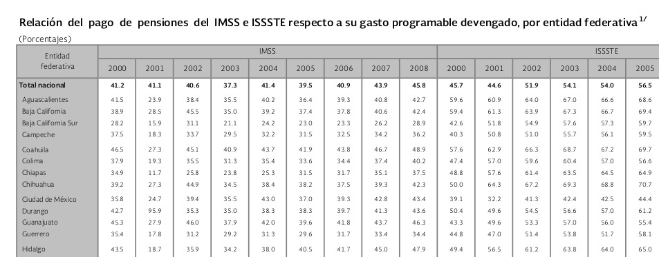

El ejercicio consiste en leer los datos y limpiarlos de forma que sean datos limpios. Los datos fueron tomados de `datos.gob.mx` y el catalogo de estados de INEGI.

# Ejercicio final / Respuestas

```r
# Respuesta
rm(list = ls())
# Funciones auxiliares
# Como son archivos de excel, muchas líneas están vacias pero R no
# lo entiende. Esta función quita esas lineas.
quita.nas <- function(df, prop.na = 0.8) {
  df <- df[, !is.na(names(df)) & names(df) != ""]
  r <- sapply(seq(nrow(df)), FUN = function(x){
    sum(is.na(df[x,]))
  })
  r <- r/ncol(df)
  df[r < prop.na, ]
}
# Como pegaremos estados a partir de sus nombres (y no una clave)
# Esta función limpia los nombres de los estados
limpia <- function(nn) {
  gsub("\\s+", " ", stringr::str_trim(nn)) %>%
    gsub("^ *|(?<= ) | *$", "", ., perl=T) %>%
    iconv(., to='ASCII//TRANSLIT') %>%
    tolower(.)
}
## Funcion para pegar la clave del estado a partir del nombre
pega.estados <- function(df, nombres = "entidad") {
  df$pega <- limpia(df[[nombres]])

  d <- rbind(readRDS("tidyr_datasets/informe/estados_p.rds"),
             data.frame(
               estado = c("00", "00", "30", "16", "15", "05")
               , pega = c("nacional", "total nacional", "veracruz"
                          , "michoacan", "estado de mexico", "coahuila")
               , stringsAsFactors = F
             )
  )

  dd <- dplyr::left_join(df, d)
  dplyr::select(dd, -pega)
}
# Limpieza de datos
df <- read_excel("tidyr_datasets/informe/M2_218.xlsx", skip = 4
                 , col_names = T)
names(df) <- c('entidad', paste0('imss_', 2000:2008)
               , paste0('issste_', 2000:2008))
df <- df %>%
  quita.nas(.) %>%
  pega.estados(.) %>%
  tidyr::gather(., key = variable, value = valor, -entidad
                , -estado, na.rm = T) %>%
  tidyr::separate(variable, c("indicador", "anio"), extra = "drop") %>%
  dplyr::mutate(indicador = paste0("pago_pensiones_", indicador))
all <- df
df <- read_excel("tidyr_datasets/informe/M2_219.xlsx", skip = 4
                 , col_names = T)
names(df) <- c('entidad', paste0('imss_', 2009:2016)
               , paste0('issste_', 2009:2016))
df <- df %>%
  quita.nas(.) %>%
  pega.estados(.) %>%
  tidyr::gather(., key = variable, value = valor, -entidad
                , -estado, na.rm = T) %>%
  tidyr::separate(variable, c("indicador", "anio")
                  , extra = "drop") %>%
  dplyr::mutate(indicador = paste0("pago_pensiones_", indicador))
all <- rbind(all, df)
all
```

```
## # A tibble: 1,122 x 5
##    entidad             estado indicador           anio  valor
##    <chr>               <chr>  <chr>               <chr> <dbl>
##  1 Total nacional      00     pago_pensiones_imss 2000   41.2
##  2 Aguascalientes      01     pago_pensiones_imss 2000   41.5
##  3 Baja California     02     pago_pensiones_imss 2000   38.9
##  4 Baja California Sur 03     pago_pensiones_imss 2000   28.2
##  5 Campeche            04     pago_pensiones_imss 2000   37.5
##  6 Coahuila            05     pago_pensiones_imss 2000   46.5
##  7 Colima              06     pago_pensiones_imss 2000   37.9
##  8 Chiapas             07     pago_pensiones_imss 2000   34.9
##  9 Chihuahua           08     pago_pensiones_imss 2000   39.2
## 10 Ciudad de México    <NA>   pago_pensiones_imss 2000   35.8
## # ... with 1,112 more rows
```

# Material adicional

[Liga a libro *en pdf* en el que se basa el taller.](https://drive.google.com/open?id=0B58pFa0ldIHJaWdMMGh3ZnFCSVk)

[Liga a libro *en html* en el que se basa el taller (en desarrollo).](https://htmlpreview.github.io/?https://raw.githubusercontent.com/salimv19/ssR/master/aprendeR/index.html)

[Otras recomendaciones de material utii](https://htmlpreview.github.io/?https://raw.githubusercontent.com/salimv19/ssR/master/aprendeR/material-adicional-3.html)